# First test of A9QH69 in lysate

Copyright (C) 2018 Martin Engqvist Lab

## Experiment

This test is identical to the LOX test done on array 2, except that this time we use E. coli lysate containing a recombinant lactate oxidase. This is the form in which we would be performing the enzyme assays in an application. We test BSA and Tween/Triton as well as different substrates, just like in the other test. The enzyme in question is A9QH69.

```r
#make sure the packages are installed
wants <- c('dplyr', 'reshape2', 'ggplot2')
has   <- wants %in% rownames(installed.packages())
if(any(!has)) install.packages(wants[!has], repos="http://ftp.acc.umu.se/mirror/CRAN/")

#load all the packages
lapply(wants, require, character.only = TRUE)
```

```
## [[1]]
## [1] TRUE
##
## [[2]]
## [1] TRUE
##
## [[3]]
## [1] TRUE
```

```r
#find the "code" directory, this should be one folder away from the project root
while (basename(getwd()) != 'code'){
  setwd("../")
  if (getwd() == '/'){
    quit(status = 1)
  }
}

#go one folder up and set as project root directory
setwd("../")
PROJ <- getwd()
setwd(paste0(PROJ, '/data/'))

#set folder paths relative to the project root
CURRENT <- getwd()
DATA <- getwd()
RAW_EXTERNAL <- paste0(DATA, '/raw_external/')
RAW_INTERNAL <- paste0(DATA, '/raw_internal/')
INTERMEDIATE = paste0(DATA, '/intermediate/')
FINAL = paste0(DATA, '/final/')

RESULTS <- paste0(PROJ, '/results/')
FIGURES <- paste0(RESULTS, 'figures/')
PICTURES <- paste0(RESULTS, 'pictures/')
```

## Setup

Let’s input the experimental paramenters for sample and assay sides

```r
# Test 2 block1

assay.df <- data.frame('assay_well'=c('A01','A02','A03','A04','A05','A06','A07','A08','A09','A10','A11','A12'),
                       'assay_tween'=c(0.1, 0.1, 0.1, 0.1, 0.1, 0.1, 0.1, 0.1, 0.1, 0.1, 0.1, 0.1),
                        'assay_tween_unit'=c('% (v/v)', '% (v/v)', '% (v/v)', '% (v/v)', '% (v/v)', '% (v/v)', '% (v/v)', '% (v/v)', '% (v/v)', '% (v/v)', '% (v/v)', '% (v/v)'),
                       'assay_triton_conc'=c(0.1, 0.1, 0.1, 0.1, 0.1, 0.1, 0.1, 0.1, 0.1, 0.1, 0.1, 0.1),
                       'assay_triton_unit'=c('% (v/v)', '% (v/v)', '% (v/v)', '% (v/v)', '% (v/v)', '% (v/v)', '% (v/v)', '% (v/v)', '% (v/v)', '% (v/v)', '% (v/v)', '% (v/v)'),
                       'assay_fluorescein_conc'=c(1.0, 1.0, 1.0, 1.0, 1.0, 1.0, 1.0, 1.0, 1.0, 1.0, 1.0, 1.0),
                       'assay_fluorescein_unit'=c('uM', 'uM', 'uM', 'uM', 'uM', 'uM', 'uM', 'uM', 'uM', 'uM', 'uM', 'uM'),
                       'assay_amplex_red_conc'=c(500.0, 500.0, 500.0, 500.0, 500.0, 500.0, 500.0, 500.0, 500.0, 500.0, 500.0, 500.0),
                       'assay_amplex_red_unit'=c('uM', 'uM', 'uM', 'uM', 'uM', 'uM', 'uM', 'uM', 'uM', 'uM', 'uM', 'uM'),
                       'assay_substrate_name'=c('none', 'glycolate', 'lactate', 'none', 'glycolate', 'lactate', 'none', 'glycolate', 'lactate', 'none', 'glycolate', 'lactate'),
                       'assay_substrate_conc'=c(0.0, 10.0, 10.0, 0.0, 10.0, 10.0, 0.0, 10.0, 10.0, 0.0, 10.0, 10.0),
                       'assay_substrate_unit'=c('mM', 'mM', 'mM', 'mM', 'mM', 'mM', 'mM', 'mM', 'mM', 'mM', 'mM', 'mM'),
                        'assay_bsa_conc'=c(0.0, 0.0, 0.0, 0.0, 0.0, 0.0, 0.2, 0.2, 0.2, 0.2, 0.2, 0.2),
                       'assay_bsa_unit'=c('mg/mL', 'mg/mL', 'mg/mL', 'mg/mL', 'mg/mL', 'mg/mL', 'mg/mL', 'mg/mL', 'mg/mL', 'mg/mL', 'mg/mL', 'mg/mL'))


sample.df <- data.frame('sample_well'=c('S01','S02','S03','S04','S05','S06','S07','S08','S09','S10','S11','S12'),
                        'sample_tween_conc'=c(0.01, 0.01, 0.01, 0.01, 0.01, 0.01, 0.1, 0.1, 0.1, 0.1, 0.1, 0.1),
                        'sample_tween_unit'=c('% (v/v)', '% (v/v)', '% (v/v)', '% (v/v)', '% (v/v)', '% (v/v)', '% (v/v)', '% (v/v)', '% (v/v)', '% (v/v)', '% (v/v)', '% (v/v)'),
                        'sample_triton_conc'=c(0.01, 0.01, 0.01, 0.01, 0.01, 0.01, 0.1, 0.1, 0.1, 0.1, 0.1, 0.1),
                        'sample_triton_unit'=c('% (v/v)', '% (v/v)', '% (v/v)', '% (v/v)', '% (v/v)', '% (v/v)', '% (v/v)', '% (v/v)', '% (v/v)', '% (v/v)', '% (v/v)', '% (v/v)'),
                        'sample_fluorescein_conc'=c(0.1, 0.1, 0.1, 0.1, 0.1, 0.1, 0.1, 0.1, 0.1, 0.1, 0.1, 0.1),
                        'sample_fluorescein_unit'=c('uM', 'uM', 'uM', 'uM', 'uM', 'uM', 'uM', 'uM', 'uM', 'uM', 'uM', 'uM'),
                        'sample_enzyme_name'=c('A9QH69', 'A9QH69', 'A9QH69', 'A9QH69', 'A9QH69', 'A9QH69', 'A9QH69', 'A9QH69', 'A9QH69', 'A9QH69', 'A9QH69', 'A9QH69'),
                        'sample_enzyme_conc'=c(0.0, 0.01, 0.02, 0.05, 0.1, 0.5, 0.0, 0.01, 0.02, 0.05, 0.1, 0.5),
                        'sample_enzyme_units'=c('relative_dilution', 'relative_dilution', 'relative_dilution', 'relative_dilution', 'relative_dilution', 'relative_dilution', 'relative_dilution', 'relative_dilution', 'relative_dilution', 'relative_dilution', 'relative_dilution', 'relative_dilution'))


head(assay.df)
```

```
##   assay_well assay_tween assay_tween_unit assay_triton_conc
## 1        A01         0.1          % (v/v)               0.1
## 2        A02         0.1          % (v/v)               0.1
## 3        A03         0.1          % (v/v)               0.1
## 4        A04         0.1          % (v/v)               0.1
## 5        A05         0.1          % (v/v)               0.1
## 6        A06         0.1          % (v/v)               0.1
##   assay_triton_unit assay_fluorescein_conc assay_fluorescein_unit
## 1           % (v/v)                      1                     uM
## 2           % (v/v)                      1                     uM
## 3           % (v/v)                      1                     uM
## 4           % (v/v)                      1                     uM
## 5           % (v/v)                      1                     uM
## 6           % (v/v)                      1                     uM
##   assay_amplex_red_conc assay_amplex_red_unit assay_substrate_name
## 1                   500                    uM                 none
## 2                   500                    uM            glycolate
## 3                   500                    uM              lactate
## 4                   500                    uM                 none
## 5                   500                    uM            glycolate
## 6                   500                    uM              lactate
##   assay_substrate_conc assay_substrate_unit assay_bsa_conc assay_bsa_unit
## 1                    0                   mM              0          mg/mL
## 2                   10                   mM              0          mg/mL
## 3                   10                   mM              0          mg/mL
## 4                    0                   mM              0          mg/mL
## 5                   10                   mM              0          mg/mL
## 6                   10                   mM              0          mg/mL
```

```r
head(sample.df)
```

```
##   sample_well sample_tween_conc sample_tween_unit sample_triton_conc
## 1         S01              0.01           % (v/v)               0.01
## 2         S02              0.01           % (v/v)               0.01
## 3         S03              0.01           % (v/v)               0.01
## 4         S04              0.01           % (v/v)               0.01
## 5         S05              0.01           % (v/v)               0.01
## 6         S06              0.01           % (v/v)               0.01
##   sample_triton_unit sample_fluorescein_conc sample_fluorescein_unit
## 1            % (v/v)                     0.1                      uM
## 2            % (v/v)                     0.1                      uM
## 3            % (v/v)                     0.1                      uM
## 4            % (v/v)                     0.1                      uM
## 5            % (v/v)                     0.1                      uM
## 6            % (v/v)                     0.1                      uM
##   sample_enzyme_name sample_enzyme_conc sample_enzyme_units
## 1             A9QH69               0.00   relative_dilution
## 2             A9QH69               0.01   relative_dilution
## 3             A9QH69               0.02   relative_dilution
## 4             A9QH69               0.05   relative_dilution
## 5             A9QH69               0.10   relative_dilution
## 6             A9QH69               0.50   relative_dilution
```

```r
# make all combinations of wells
mixed.df <- expand.grid(sample.df$sample_well, assay.df$assay_well)

# fix the colnames
colnames(mixed.df) <- c('sample_well', 'assay_well')

# add in the original data
mixed.df <- merge(mixed.df, sample.df, by='sample_well')
mixed.df <- merge(mixed.df, assay.df, by='assay_well')


# calculate final
mixed.df$final_well <- paste(mixed.df$sample_well, mixed.df$assay_well, sep='-')

mixed.df$final_fluorescein_conc <- mixed.df$assay_fluorescein_conc/10 + mixed.df$sample_fluorescein_conc/1.1
mixed.df$final_fluorescein_unit <- mixed.df$assay_fluorescein_unit

mixed.df$final_amplex_red_conc <- mixed.df$assay_amplex_red_conc/10
mixed.df$final_amplex_red_unit <- mixed.df$assay_amplex_red_unit

mixed.df$final_substrate_name <- mixed.df$assay_substrate_name
mixed.df$final_substrate_conc <- mixed.df$assay_substrate_conc/10
mixed.df$final_substrate_unit <- mixed.df$assay_substrate_unit

mixed.df$final_bsa_conc <- mixed.df$assay_bsa_conc/10
mixed.df$final_bsa_unit <- mixed.df$assay_bsa_unit

mixed.df$final_enzyme_name <- mixed.df$sample_enzyme_name
mixed.df$final_enzyme_conc <- mixed.df$sample_enzyme_conc/1.1
mixed.df$final_enzyme_unit <- mixed.df$sample_enzyme_unit

head(mixed.df)
```

```
##   assay_well sample_well sample_tween_conc sample_tween_unit
## 1        A01         S01              0.01           % (v/v)
## 2        A01         S02              0.01           % (v/v)
## 3        A01         S04              0.01           % (v/v)
## 4        A01         S09              0.10           % (v/v)
## 5        A01         S11              0.10           % (v/v)
## 6        A01         S12              0.10           % (v/v)
##   sample_triton_conc sample_triton_unit sample_fluorescein_conc
## 1               0.01            % (v/v)                     0.1
## 2               0.01            % (v/v)                     0.1
## 3               0.01            % (v/v)                     0.1
## 4               0.10            % (v/v)                     0.1
## 5               0.10            % (v/v)                     0.1
## 6               0.10            % (v/v)                     0.1
##   sample_fluorescein_unit sample_enzyme_name sample_enzyme_conc
```

[output cut: 62 more lines]

```r
tail(mixed.df)
```

```
##     assay_well sample_well sample_tween_conc sample_tween_unit
## 139        A12         S08              0.10           % (v/v)
## 140        A12         S01              0.01           % (v/v)
## 141        A12         S07              0.10           % (v/v)
## 142        A12         S11              0.10           % (v/v)
## 143        A12         S12              0.10           % (v/v)
## 144        A12         S05              0.01           % (v/v)
##     sample_triton_conc sample_triton_unit sample_fluorescein_conc
## 139               0.10            % (v/v)                     0.1
## 140               0.01            % (v/v)                     0.1
## 141               0.10            % (v/v)                     0.1
## 142               0.10            % (v/v)                     0.1
## 143               0.10            % (v/v)                     0.1
## 144               0.01            % (v/v)                     0.1
##     sample_fluorescein_unit sample_enzyme_name sample_enzyme_conc
```

[output cut: 69 more lines]

## Load data

So now we have the conditions in the final wells. Time to load up the measured data. From the data file that goes with this script (1_1530021086_array_3_raw.csv) I manually exported the ROX and FAM signal separately to tsv files. Load the data and then combine with my condition file.

```r
# read the experimental data obtained from the BioMark
rox.df <- read.table(paste(INTERMEDIATE, 'flex_six_first_test', 'Array_3', '3_1530021086_array_3_rox.tsv', sep='/'), sep='\t', header=TRUE)
colnames(rox.df) <- c(c('final_well'), paste0('rox_cycle_', seq(length(colnames(rox.df))-1)))

fam.df <- read.table(paste(INTERMEDIATE, 'flex_six_first_test', 'Array_3', '4_1530021086_array_3_fam.tsv', sep='/'), sep='\t', header=TRUE)
colnames(fam.df) <- c(c('final_well'), paste0('fam_cycle_', seq(length(colnames(fam.df))-1)))


# Add the data into my frame with concentration info
all.df <- merge(mixed.df, rox.df, by='final_well')
all.df <- merge(all.df, fam.df, by='final_well')

head(all.df)
```

```
##   final_well assay_well sample_well sample_tween_conc sample_tween_unit
## 1    S01-A01        A01         S01              0.01           % (v/v)
## 2    S01-A02        A02         S01              0.01           % (v/v)
## 3    S01-A03        A03         S01              0.01           % (v/v)
## 4    S01-A04        A04         S01              0.01           % (v/v)
## 5    S01-A05        A05         S01              0.01           % (v/v)
## 6    S01-A06        A06         S01              0.01           % (v/v)
##   sample_triton_conc sample_triton_unit sample_fluorescein_conc
## 1               0.01            % (v/v)                     0.1
## 2               0.01            % (v/v)                     0.1
## 3               0.01            % (v/v)                     0.1
## 4               0.01            % (v/v)                     0.1
## 5               0.01            % (v/v)                     0.1
## 6               0.01            % (v/v)                     0.1
##   sample_fluorescein_unit sample_enzyme_name sample_enzyme_conc
```

[output cut: 97 more lines]

Looks good! Let’s export this to a flatfile for future use.

```r
write.table(all.df, file=paste(FINAL, 'flex_six_first_test', 'array_3_all_data_combined.tsv', sep='/'), sep='\t', row.names=FALSE)
```

## Plotting results

Time to plot!

A look at the raw data as a heatmap.

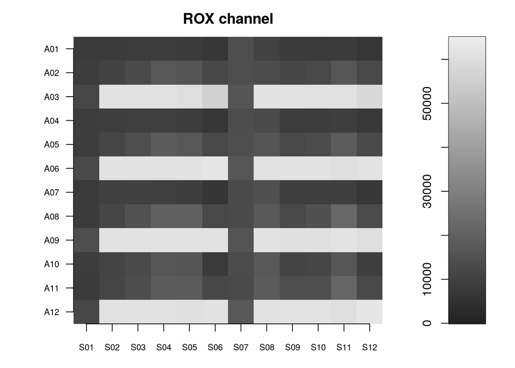

```r
# ----- Define a function for plotting a matrix ----- #
# from http://www.phaget4.org/R/image_matrix.html
myImagePlot <- function(x, ...){
     min <- 0
     max <- 65000
     yLabels <- rownames(x)
     xLabels <- colnames(x)
     title <-c()
  # check for additional function arguments
  if( length(list(...)) ){
    Lst <- list(...)
    if( !is.null(Lst$zlim) ){
       min <- Lst$zlim[1]
       max <- Lst$zlim[2]
    }
    if( !is.null(Lst$yLabels) ){
       yLabels <- c(Lst$yLabels)
    }
    if( !is.null(Lst$xLabels) ){
       xLabels <- c(Lst$xLabels)
    }
    if( !is.null(Lst$title) ){
       title <- Lst$title
    }
  }
# check for null values
if( is.null(xLabels) ){
   xLabels <- c(1:ncol(x))
}
if( is.null(yLabels) ){
   yLabels <- c(1:nrow(x))
}

layout(matrix(data=c(1,2), nrow=1, ncol=2), widths=c(4,1), heights=c(1,1))

 # Red and green range from 0 to 1 while Blue ranges from 1 to 0
 ColorRamp <- colorRampPalette(c('#222222', '#EEEEEE'))(n = 256)
 ColorLevels <- seq(min, max, length=length(ColorRamp))

 # Reverse Y axis
 reverse <- nrow(x) : 1
 yLabels <- yLabels[reverse]
 x <- x[reverse,]

 # Data Map
 par(mar = c(3,5,2.5,2))
 image(1:length(xLabels), 1:length(yLabels), t(x), col=ColorRamp, xlab="",
 ylab="", axes=FALSE, zlim=c(min,max))
 if( !is.null(title) ){
    title(main=title)
 }
axis(BELOW<-1, at=1:length(xLabels), labels=xLabels, cex.axis=0.7)
 axis(LEFT <-2, at=1:length(yLabels), labels=yLabels, las= HORIZONTAL<-1,
 cex.axis=0.7)

 # Color Scale
 par(mar = c(3,2.5,2.5,2))
 image(1, ColorLevels,
      matrix(data=ColorLevels, ncol=length(ColorLevels),nrow=1),
      col=ColorRamp,
      xlab="",ylab="",
      xaxt="n")

 layout(1)
}
# ----- END plot function ----- #



make_heatmap <- function(mat_data){

  color_scale <- colorRampPalette(c('#1A1A1A', '#EEEEEE'))(n = 256)

  # adjust the color scale. Max value sems to be around 65,000
  max_val <- max(mat_data)
  if (max_val > 65000){
    color_end <- 256
  }else{
    color_end <- round((max_val/65000) * 256)
  }
  color_scale <- color_scale[1:color_end]

  image(mat_data,
          axes=FALSE,
          col = color_scale,
          xlab='Assay',
          ylab='Sample')
}


# make a subset of the data frames for plotting
rox_data.df <- all.df[, which(names(all.df) %in% c('assay_well', 'sample_well', 'rox_cycle_15'))]
fam_data.df <- all.df[, which(names(all.df) %in% c('assay_well', 'sample_well', 'fam_cycle_15'))]

# make wide format
rox_data_wide.df <- dcast(rox_data.df, assay_well ~ sample_well, value.var='rox_cycle_15')
fam_data_wide.df <- dcast(fam_data.df, assay_well ~ sample_well, value.var='fam_cycle_15')

# use first column as row names
rox.mat_data <- data.matrix(rox_data_wide.df[, 2:length(names(rox_data_wide.df))])
rnames <- rox_data_wide.df[,'assay_well']   # assign labels in the "File" column to "rnames"
rownames(rox.mat_data) <- rnames

fam.mat_data <- data.matrix(fam_data_wide.df[, 2:length(names(fam_data_wide.df))])
rnames <- fam_data_wide.df[,'assay_well']   # assign labels in the "File" column to "rnames"
rownames(fam.mat_data) <- rnames


# Now make the heatmap
myImagePlot(rox.mat_data, title=('ROX channel'))
```

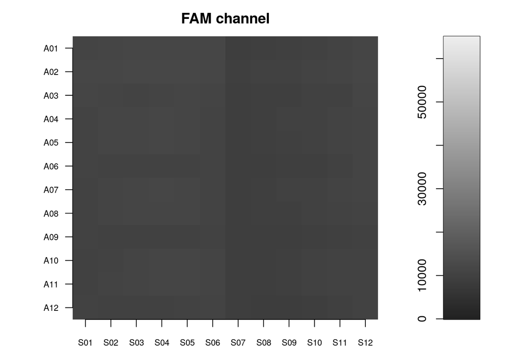

```r
myImagePlot(fam.mat_data, title=('FAM channel'))
```

Let’s first just have a look at all the ROX and FAM channel data.

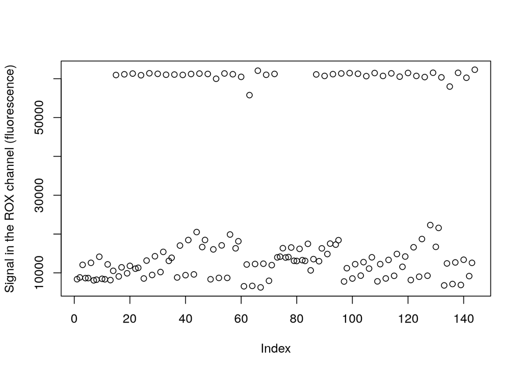

```r
plot(all.df$rox_cycle_15,
     ylab='Signal in the ROX channel (fluorescence)')
```

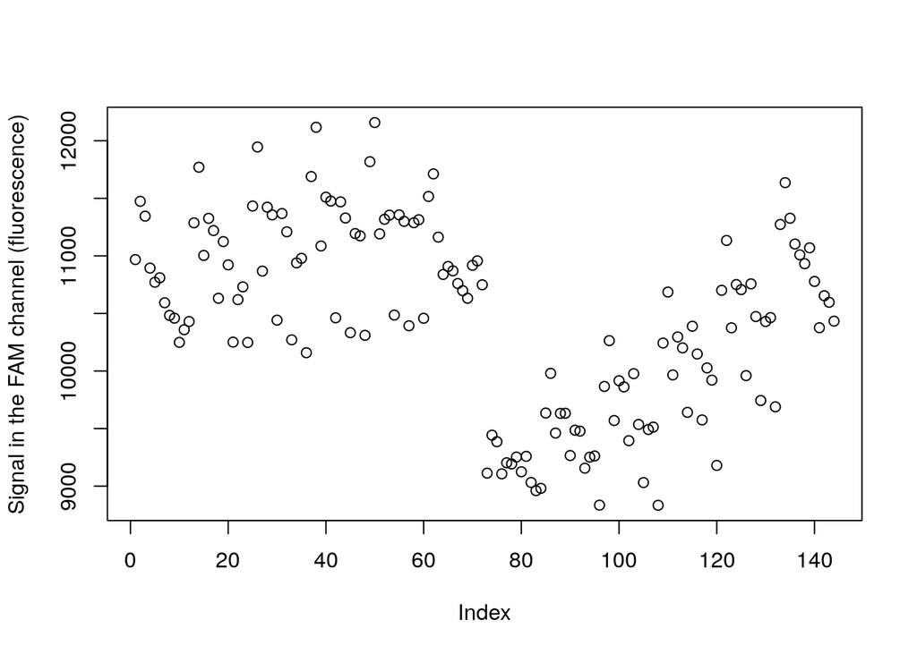

```r
plot(all.df$fam_cycle_15,
     ylab='Signal in the FAM channel (fluorescence)')
```

First, let’s see what the fluorescein loading control looks like.

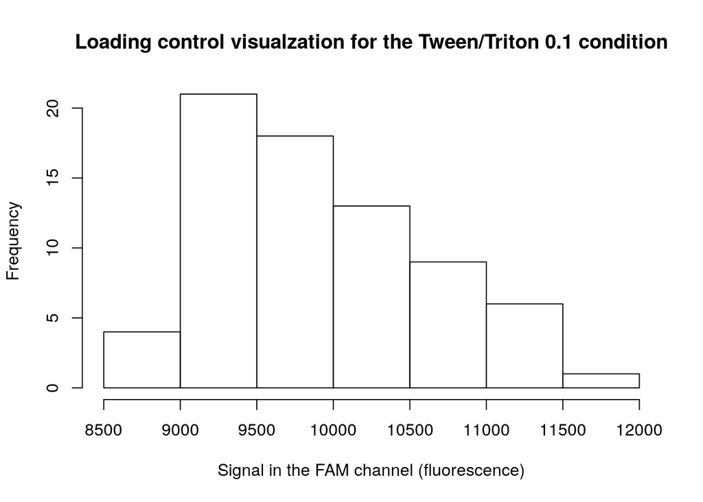

```r
hist(all.df[all.df$sample_tween_conc==0.1, ]$fam_cycle_15,
     main='Loading control visualzation for the Tween/Triton 0.1 condition',
     xlab='Signal in the FAM channel (fluorescence)')
```

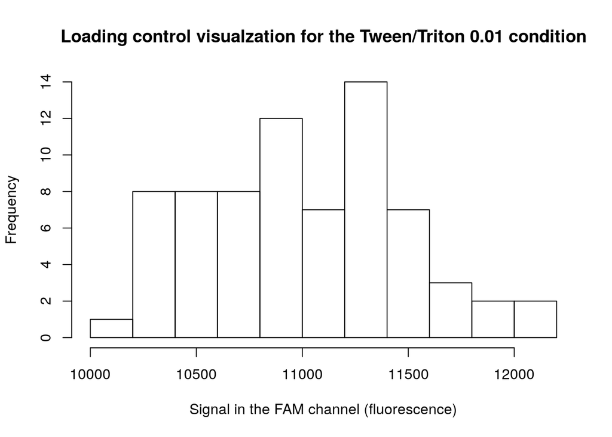

```r
hist(all.df[all.df$sample_tween_conc==0.01, ]$fam_cycle_15,
     main='Loading control visualzation for the Tween/Triton 0.01 condition',
     xlab='Signal in the FAM channel (fluorescence)')
```

This looks good. Any bad loading should lead to half the signal. I don’t seem to see that. So both tween/triton concentrations seem to work well to load E. coli lysate.

Next let’s compare whether the sample tween/triton concentration had an effect on the enzyme activity.

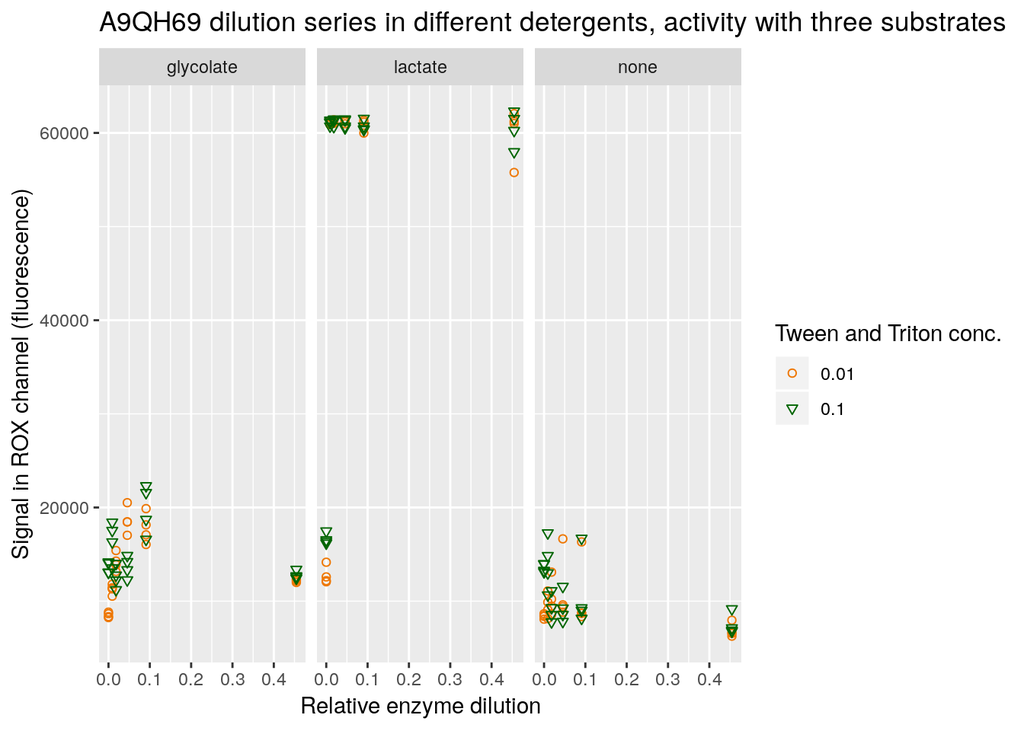

```r
ggplot(all.df, aes(x=final_enzyme_conc, y=rox_cycle_15, shape = factor(sample_tween_conc), color = factor(sample_tween_conc)))+
    geom_point() +
    scale_color_manual(values = c('0.01' = 'darkorange2', '0.1' = 'darkgreen'), name='Tween and Triton conc.') +
    scale_shape_manual(values = c('0.01' = 21, '0.1' = 25), name='Tween and Triton conc.') +
    ggtitle('A9QH69 dilution series in different detergents, activity with three substrates') +
    xlab('Relative enzyme dilution') +
    ylab('Signal in ROX channel (fluorescence)') +
    facet_grid(~final_substrate_name)
```

The detergent seems to have very little effect on the activity. Oddly though there seems to be a falloff in activity at the lowest dilution 2x dilution (the 0.5 value). This is more pronounced for glycolate, probably because the lactate signal is maxed out and we cannot accurately see those values in the middle. So somwhat higher dilution rates appear to be optimal to detect activity. About 10x dilution or so.

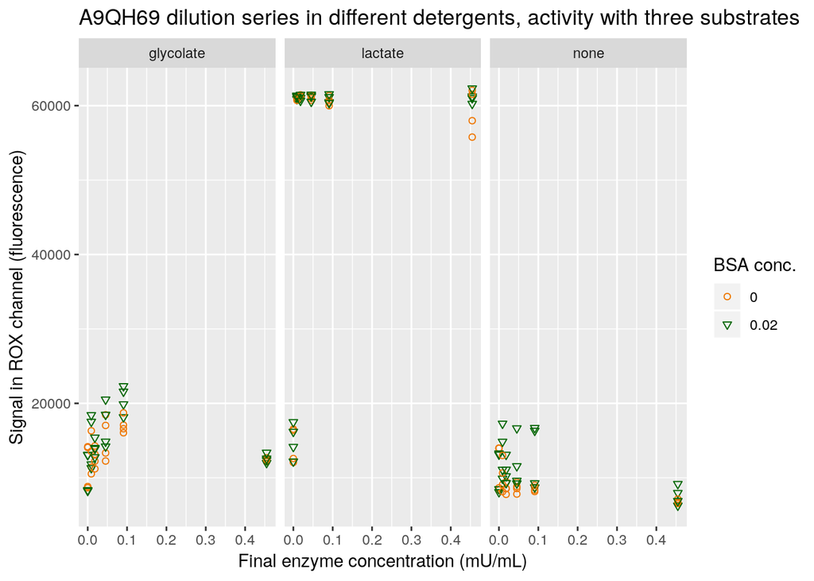

```r
ggplot(all.df, aes(x=final_enzyme_conc, y=rox_cycle_15, shape = factor(final_bsa_conc), color = factor(final_bsa_conc)))+
    geom_point() +
    scale_color_manual(values = c('0' = 'darkorange2', '0.02' = 'darkgreen'), name='BSA conc.') +
    scale_shape_manual(values = c('0' = 21, '0.02' = 25), name='BSA conc.') +
    ggtitle('A9QH69 dilution series in different detergents, activity with three substrates') +
    xlab('Final enzyme concentration (mU/mL)') +
    ylab('Signal in ROX channel (fluorescence)') +
    facet_grid(~final_substrate_name)
```

As previously seen with LOX, the BSA has absolutely no effect on the assays (compare orange and green). So peroxidase adsorption is not a problem it seems.

We did do “kinetic” measurements of the enzymes. Meeaning that we cycled 15 times at 20C for 1 minute. That gives us 15 measurements of fluorescence. I’m interested in seeing whether we can actually see signal increase over time.

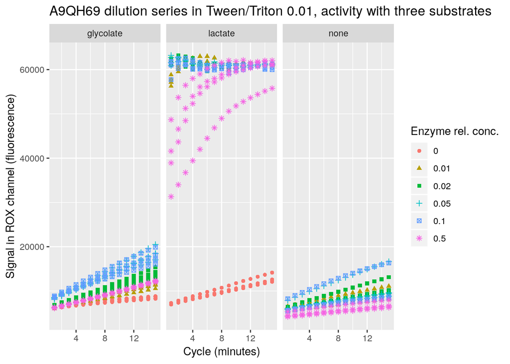

```r
# subset the data
rox_data.df <- all.df[, which(names(all.df) %in% c('assay_substrate_name', 'final_bsa_conc', 'sample_tween_conc', 'sample_enzyme_conc', 'rox_cycle_1', 'rox_cycle_2', 'rox_cycle_3', 'rox_cycle_4', 'rox_cycle_5', 'rox_cycle_6', 'rox_cycle_7', 'rox_cycle_8', 'rox_cycle_9', 'rox_cycle_10', 'rox_cycle_11', 'rox_cycle_12', 'rox_cycle_13', 'rox_cycle_14', 'rox_cycle_15'))]
fam_data.df <- all.df[, which(names(all.df) %in% c('assay_substrate_name', 'final_bsa_conc', 'sample_tween_conc', 'sample_enzyme_conc', 'fam_cycle_1', 'fam_cycle_2', 'fam_cycle_3', 'fam_cycle_4', 'fam_cycle_5', 'fam_cycle_6', 'fam_cycle_7', 'fam_cycle_8', 'fam_cycle_9', 'fam_cycle_10', 'fam_cycle_11', 'fam_cycle_12', 'fam_cycle_13', 'fam_cycle_14', 'fam_cycle_15'))]


# I need to convert the data from wide format to long format
rox_data_long.df <- melt(rox_data.df, id=c('assay_substrate_name', 'final_bsa_conc', 'sample_tween_conc', 'sample_enzyme_conc'))
fam_data_long.df <- melt(fam_data.df, id=c('assay_substrate_name', 'final_bsa_conc', 'sample_tween_conc', 'sample_enzyme_conc'))

# Convert the cycle number from text to ints
rox_data_long_cycles.df <- rox_data_long.df
rox_data_long_cycles.df$variable <- as.numeric(gsub("rox_cycle_", '', rox_data_long.df$variable) )

fam_data_long_cycles.df <- fam_data_long.df
fam_data_long_cycles.df$variable <- as.numeric(gsub("fam_cycle_", '', fam_data_long.df$variable) )


# Done. Ready to plot now
ggplot(rox_data_long_cycles.df[rox_data_long_cycles.df$sample_tween_conc == 0.01, ], aes(x=variable, y=value, shape = factor(sample_enzyme_conc), color = factor(sample_enzyme_conc)))+
    geom_point() +
    guides(color=guide_legend(title="Enzyme rel. conc.")) +
    guides(shape=guide_legend(title="Enzyme rel. conc.")) +
    ggtitle('A9QH69 dilution series in Tween/Triton 0.01, activity with three substrates') +
    xlab('Cycle (minutes)') +
    ylab('Signal in ROX channel (fluorescence)') +
    facet_grid(~assay_substrate_name)
```

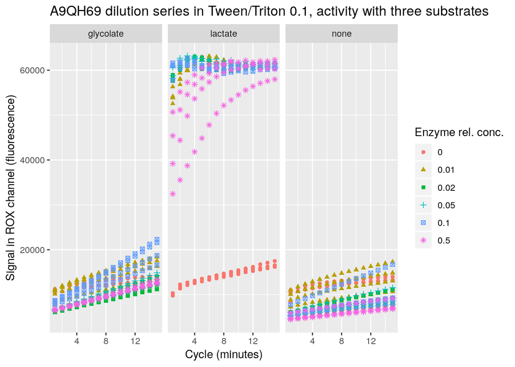

```r
ggplot(rox_data_long_cycles.df[rox_data_long_cycles.df$sample_tween_conc == 0.1, ], aes(x=variable, y=value, shape = factor(sample_enzyme_conc), color = factor(sample_enzyme_conc)))+
    geom_point() +
    guides(color=guide_legend(title="Enzyme rel. conc.")) +
    guides(shape=guide_legend(title="Enzyme rel. conc.")) +
    ggtitle('A9QH69 dilution series in Tween/Triton 0.1, activity with three substrates') +
    xlab('Cycle (minutes)') +
    ylab('Signal in ROX channel (fluorescence)') +
    facet_grid(~assay_substrate_name)
```